# 72 Calculus plots with Makie

## 72.5 Contour plots (`contour`, `contourf`, `heatmap`)

For a function $z = f(x,y)$ an alternative to a surface plot, is a contour plot. That is, for different values of $c$ the level curves $f(x,y)=c$ are drawn.

For a function $f(x,y)$, the syntax for generating a contour plot follows that for `surface`.

For example, using the `peaks` function, previously defined, we have a contour plot over the region $[-5,5]\times[-5,5]$ is generated through `contour(xs, ys, peaks)`. A figure is shown in Figure 72.27`.

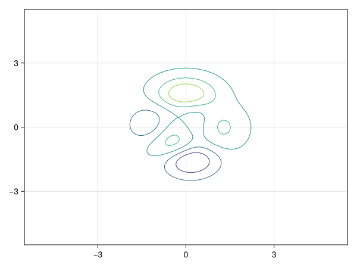

```julia
xs = ys = range(-5, 5, length=100)
contour(xs, ys, peaks)
```

Figure 72.27: Contour plot of `peaks`

The default of $5$ levels can be adjusted using the contour function’s `levels` keyword. Figure 72.28 show the `peaks` function with `levels = 20`. The `levels` argument can also specify precisely what levels are to be drawn.

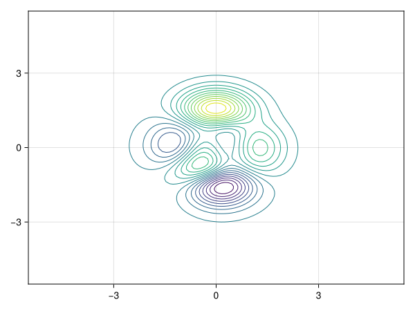

```julia
contour(xs, ys, peaks; levels = 20)
```

Figure 72.28: Contour plot of `peaks` with the display of 20 levels specified

The contour graph makes identification of peaks and valleys easy as the limits of patterns of nested contour lines.

A *filled* contour plot is produced by `contourf`, as seen in Figure 72.29.

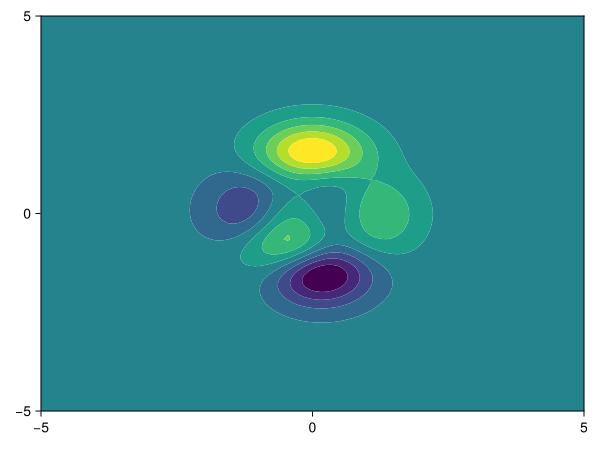

```julia
contourf(xs, ys, peaks)
```

Figure 72.29: The `contourf` command produces filled contour plots

A related, but alternative visualization, using color to represent magnitude is a heatmap, produced by the `heatmap` function. The calling syntax is similar to `contour` and `surface`. Figure 72.30 shows peaks and valleys through “hotspots” on the graph.

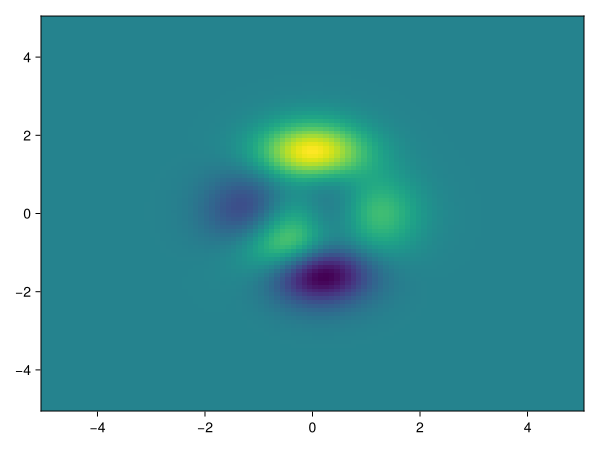

```julia
heatmap(xs, ys, peaks)
```

Figure 72.30: Heatmap of `peaks` function

##### Example

The `MakieGallery` package includes an example of a surface plot with both a wireframe and 2D contour graph added. It is replicated here using the `peaks` function scaled by $5$.

The function and domain to plot are described by:

```julia
xs = ys = range(-5, 5, length=51)
zs = peaks.(xs, ys') / 5;
```

The `zs` were generated, as `wireframe` does not provide the interface for passing a function.

The `surface` and `wireframe` graphics are produced as follows. In the following we manually create the figure and axis object (using `Figure` and `Axis` as shown). We do this to set the viewing angle through the `elevation` argument to the axis object. We plot onto this axis in producing Figure 72.31 and then display the `Figure` object.

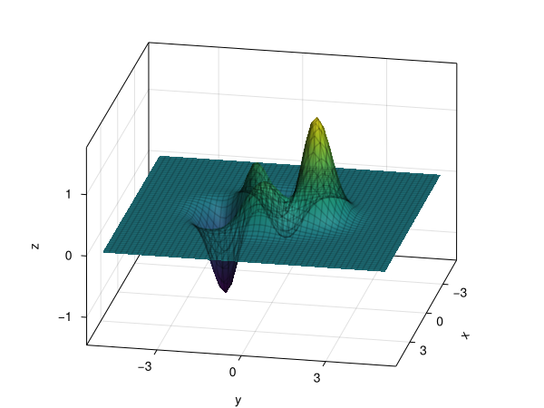

```julia
fig = Figure()
ax3 = Axis3(fig[1,1];   # upper left of `fig`
            elevation=pi/9, azimuth=pi/16)

surface!(ax3, xs, ys, zs)
wireframe!(ax3, xs, ys, zs;
           overdraw = true, transparency = true,
           color = (:black, 0.1))

fig                    # Figure object displays graphic
```

Figure 72.31: Surface and wireframe for the `peaks` function

Next, we add a contour graph to Figure 72.31 to produce Figure 72.32. A simple call via `contour!(scene, xs, ys, zs)` will place the contour at the $z=0$ level which will make it hard to read. Rather, placing at the “bottom” of the figure is desirable.

To identify that the minimum value, is identified (and rounded) and the argument `transformation = (:xy, zmin)` is passed to `contour!`:

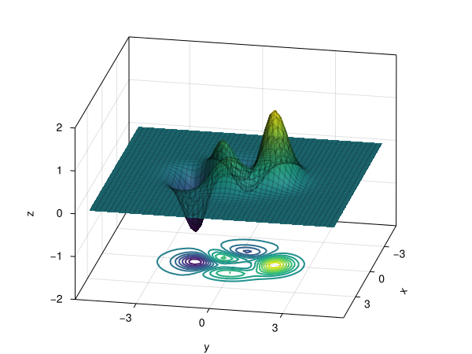

```julia
zmin, zmax = extrema(zs)
zmin, zmax = floor(zmin), ceil(zmax) # round down/up
contour!(ax3, xs, ys, zs;
         levels = 15, linewidth = 2,
         transformation = (:xy, zmin))
zlims!(ax3, zmin, zmax)

fig
```

Figure 72.32: Surface, wireframe, and contour for the `peaks` function

The `transformation` plot attribute sets the “plane” (one of `:xy`, `:yz`, or `:xz`) at a location, in this example `zmin`.

The manual construction of a figure and an axis object will be further discussed later.

### 72.5.1 Three dimensional contour plots

The `contour` function can also plot $3$-dimensional contour plots. Concentric spheres, contours of $x^2 + y^2 + z^2 = c$ for $c > 0$ are presented in Figure 72.33.

[figure not shown]

```julia
f(x,y,z) = x^2 + y^2 + z^2
xs = ys = zs = range(-3, 3, length=100)

contour(xs, ys, zs, f)
```

Figure 72.33: Three dimensional contour plot

### 72.5.2 Implicitly defined curves and surfaces

Suppose $f$ is a scalar-valued function. If `f` takes two variables for its input, then the equation $f(x,y) = 0$ implicitly defines $y$ as a function of $x$; $y$ can be visualized *locally* with a curve. If $f$ takes three variables for its input, then the equation $f(x,y,z)=0$ implicitly defines $z$ as a function of $x$ and $y$; $z$ can be visualized *locally* with a surface.

#### Implicitly defined curves

The graph of an equation is the collection of all $(x,y)$ values satisfying the equation. This is more general than the graph of a function, which can be viewed as the graph of the equation $y=f(x)$. An equation in $x$-$y$ can be graphed if the set of solutions to a related equation $f(x,y)=0$ can be identified, as one can move all terms to one side of an equation and define $f$ as the rule of the side with the terms. The implicit function theorem ensures that under some conditions, *locally* near a point $(x, y)$, the value $y$ can be represented as a function of $x$. So, the graph of the equation $f(x,y)=0$ can be produced by stitching together these local function representations.

The contour graph can produce these graphs by setting the `levels` argument to `[0]`.

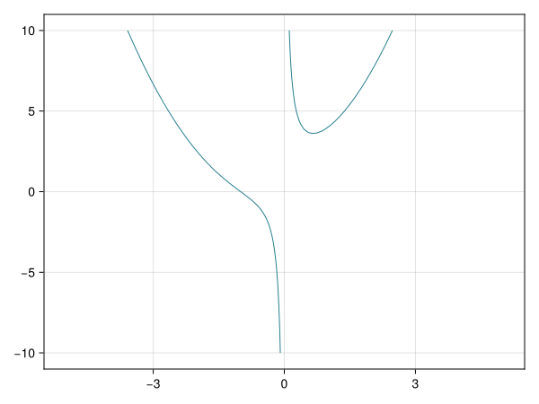

```julia
f(x,y) = x^3 + x^2 + x + 1 - x*y        # solve x^3 + x^2 + x + 1 = x*y
xs = range(-5, 5, length=100)
ys = range(-10, 10, length=100)

contour(xs, ys, f; levels=[0])
```

Figure 72.34: Using `contour` to graph an implicitly defined function

The `implicitPlots.jl` function uses the `Contour` package along with a `Plots` recipe to plot such graphs. Here we see how to use `Makie` in a similar manner:

```julia
import Contour

function implicit_plot(xs, ys, f; kwargs...)
    fig = Figure()
    ax = Axis(fig[1,1])
    implicit_plot!(ax, xs, ys, f; kwargs...)
    fig
end

function implicit_plot!(ax, xs, ys, f; kwargs...)
    z = [f(x, y) for x in xs, y in ys]
    cs = Contour.contour(collect(xs), collect(ys), z, 0.0)
    ls = Contour.lines(cs)

    isempty(ls) && error("empty")

    for l ∈ ls
        us, vs = Contour.coordinates(l)
        lines!(ax, us, vs; kwargs...)
    end

end
```

#### Implicitly defined surfaces, $F(x,y,z)=0$

To plot the equation $F(x,y,z)=0$, for $F$ a scalar-valued function, again the implicit function theorem says that, under conditions, near any solution $(x,y,z)$, $z$ can be represented as a function of $x$ and $y$, so the graph will look like surfaces stitched together.

With `Makie`, many implicitly defined surfaces can be adequately represented using `contour` with the attribute `levels=[0]`. We will illustrate this technique.

**NoteGLMakie**

The `CairoMakie` backend does not handle these next few plots, so we use `GLMakie.contour` in the following after importing with:

```julia
import GLMakie
```

To begin, we plot a sphere implicitly as a solution to $F(x,y,z) = x^2 + y^2 + z^2 - 1 = 0$ in Figure 72.35.

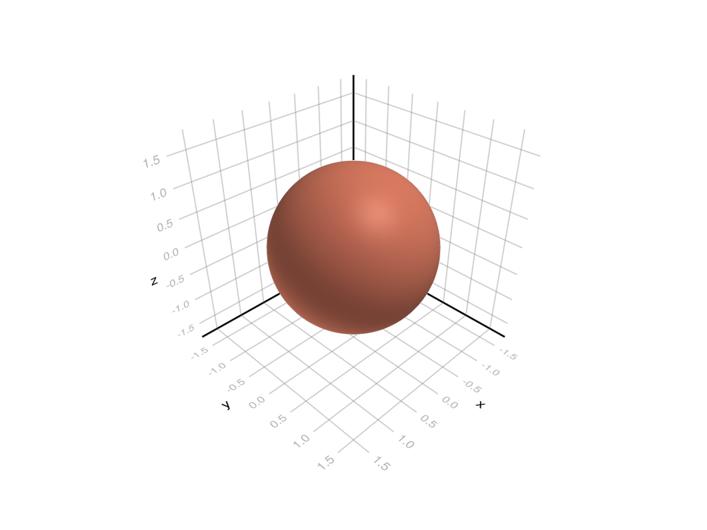

```julia
f(x) = norm(x)^2 - 1
ϕ(x,y,z) = (x,y,z)
xs = ys = zs = range(-3/2, 3/2, 100)
GLMakie.contour(xs, ys, zs, f∘ϕ; levels=[0], colormap=:RdBu)
```

Figure 72.35: Three dimensional implicitly defined surface plotted with `contour`

Figure 72.36 visualizes an intersection of a sphere with another figure. To show the different surfaces, different colormaps are chosen.

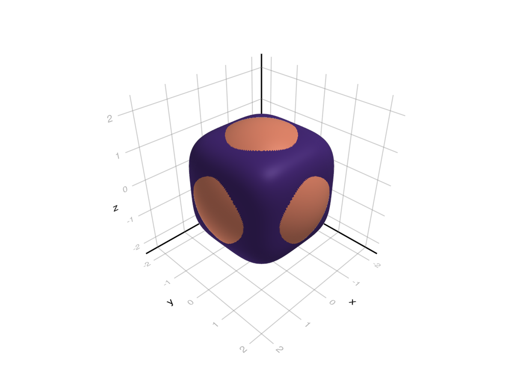

```julia
r₂(x) = sum(x.^2) - 2 # a sphere
r₄(x) = sum(x.^4) - 1
ϕ(x,y,z) = (x,y,z)

xs = ys = zs = range(-2, 2, 100)
GLMakie.contour(xs, ys, zs, r₂∘ϕ; levels = [0], colormap=:RdBu)
GLMakie.contour!(xs, ys, zs, r₄∘ϕ; levels = [0], colormap=:viridis)
current_figure()
```

Figure 72.36: Two implicitly defined surfaces in three dimensions disambiguated through different colormaps

Figure 72.37 presents an example from [Wikipedia](https://en.wikipedia.org/wiki/Implicit_surface) showing an implicit surface of genus $2$.

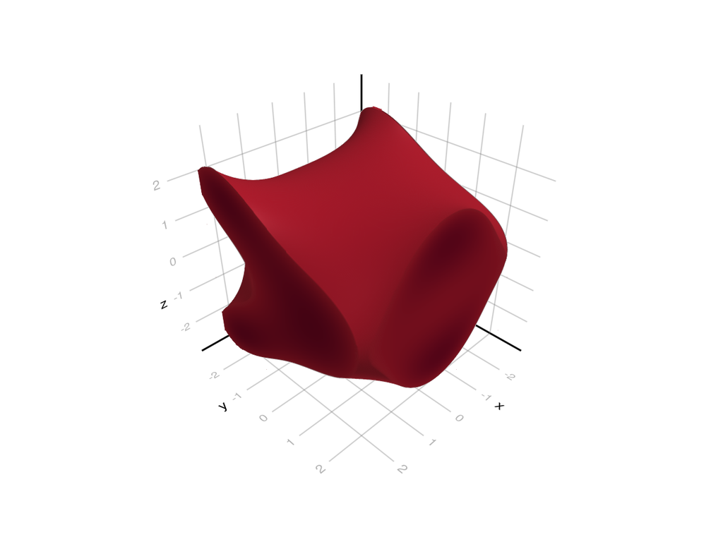

```julia
f(x,y,z) = 2y*(y^2 -3x^2)*(1-z^2) + (x^2 +y^2)^2 - (9z^2-1)*(1-z^2)
xs = ys = zs = range(-5/2, 5/2, 100)
GLMakie.contour(xs, ys, zs, f; levels=[0], colormap=:RdBu)
```

Figure 72.37: Implicit surface of a genus 2 function. This figure does not render well though, as the hole is not displayed.

The `Implicit3DPlotting` package takes an approach like `ImplicitPlots` to represent these surfaces. It replaces the `Contour` package computation with a $3$-dimensional alternative provided through the `Meshing` and `GeometryBasics` packages. This package has a `plot_implicit_surface` function that does something similar as just illustrated, but handles the “hole” not shown in Figure 72.37.

The `plot_implicit_surface` takes a function of a single argument, so we wrap `f` within `splat` which takes that single argument and “splats” them so `f` can be used. The result appears in Figure 72.38.

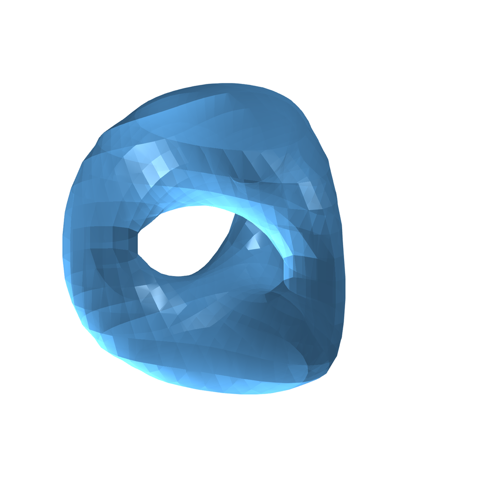

```julia
using Implicit3DPlotting
plot_implicit_surface(splat(f); xlims=(-5/2, 5/2), ylims=(-5/2, 5/2))
```

Figure 72.38: Implicit surface of a genus 2 function. This surface, rendered with the `Implicit3DPlotting` package, shows the holes present in the surface.

For one last example from Wikipedia, we have the Cassini oval which “can be defined as the point set for which the *product* of the distances to $n$ given points is constant.”

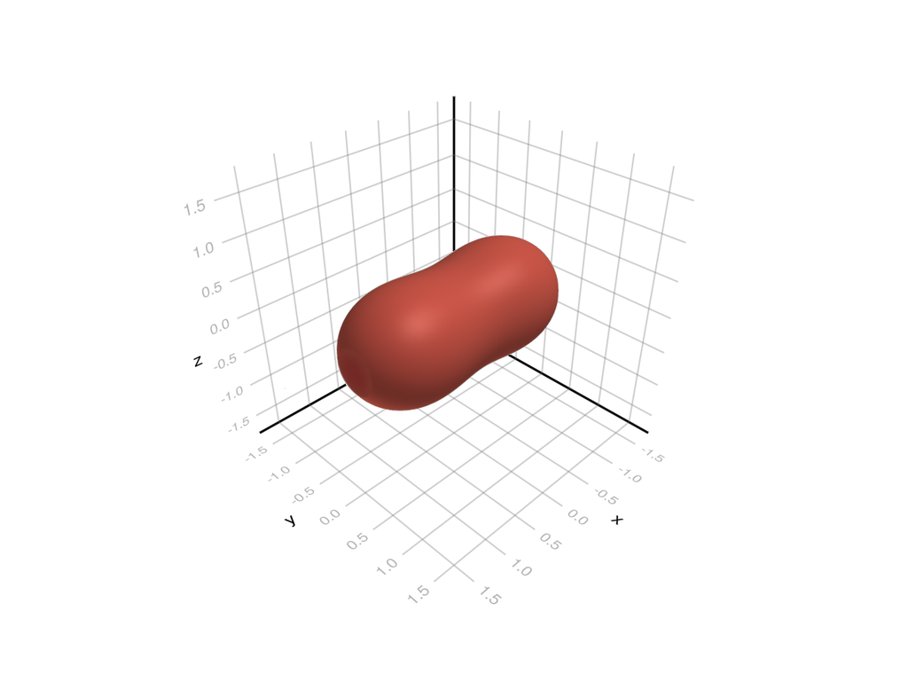

```julia
function cassini(λ, ps = ((1,0,0), (-1, 0, 0))) # cassini returns a function
    n = length(ps)
    x -> prod(norm(x .- p) for p ∈ ps) - λ^n
end
xs = ys = zs = range(-3/2, 3/2, 100)
GLMakie.contour(xs, ys, zs, cassini(0.80) ∘ ϕ; levels=[0], colormap=:RdBu)
```

Figure 72.39: Cassini oval implicitly defined

## 72.6 Vector fields. Visualizations of $f:R^2 \rightarrow R^2$

The vector field $f(x,y) = \langle y, -x \rangle$ can be visualized as a set of vectors, $f(x,y)$, positioned at a grid. These arrows can be visualized with the `arrows` function. The `arrows` function is passed a vector of points for the anchors and a vector of points representing the vectors.

We can generate these on a regular grid through:

```julia
f(x, y) = [y, -x]
xs = ys = -5:5
pts = vec(Point2.(xs, ys'))
dus = vec(Point2.(f.(xs, ys')));
first(pts), first(dus)  # show an example
```

```
([-5, -5], [-5, 5])
```

Broadcasting over `(xs, ys')` ensures each pair of possible values is encountered. The `vec` call reshapes an array into a vector.

Calling `arrows` on the prepared data produces the graphic:

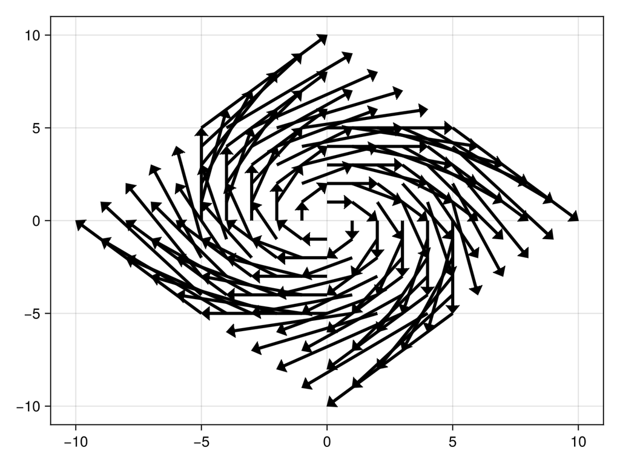

```julia
arrows2d(pts, dus)
```

Figure 72.40: Vectorfield plot generated by `arrows2d`. Modification is needed.

The grid seems rotated at first glance; but is also confusing. This is due to the length of the vectors as the $(x,y)$ values get farther from the origin. Plotting the *normalized* values (each will have length $1$) can be done easily using `norm` (which is found in the standard `LinearAlgebra` library):

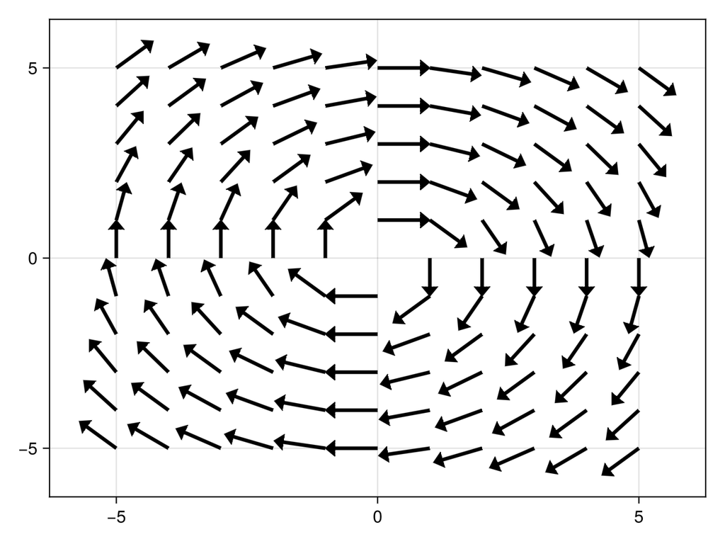

```julia
dvs = dus ./ norm.(dus)
arrows2d(pts, dvs)
```

Figure 72.41: Vectorfield plot generated by `arrows2d` after modification

The rotational pattern in Figure 72.41 is much clearer than from Figure 72.40.

The `streamplot` function also illustrates this phenomenon. This implements an “algorithm [that] puts an arrow somewhere and extends the streamline in both directions from there. Then, it chooses a new position (from the remaining ones), repeating the exercise until the streamline gets blocked, from which on a new starting point, the process repeats.”

The `streamplot` function expects a `Point` not a pair of values, so we adjust `f` slightly and call the function using the pattern `streamplot(g, xs, ys)`:

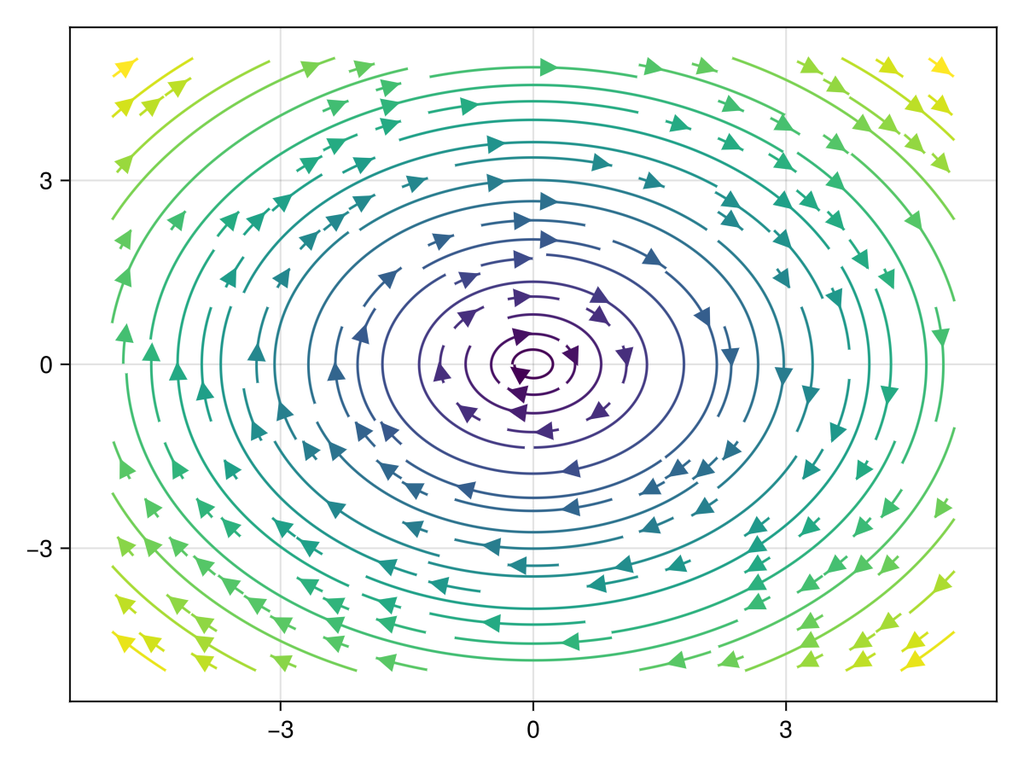

```julia
f(x, y) = [y, -x]
g(xs) = Point2(f(xs...))

streamplot(g, -5..5, -5..5)
```

Figure 72.42: Graph produced by `streamplot`

(We used interval notation to set the viewing range, a range could also be used.)

**NoteNote**

The calling pattern of `streamplot` is different than other functions, such as `surface`, in that the function comes first.

## 72.7 Layoutables

The `FigureAxisPlot` comprises an enclosing figure and one or more axes. These can be constructed directly through a pattern like the following:

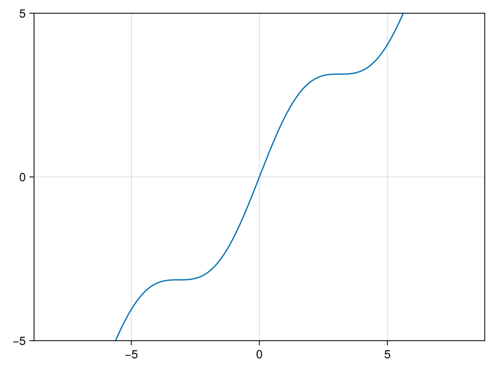

```julia
F = Figure()        # can pass size=(w,h)
ax = Axis(F[1,1])   # can pass title, xlabel, ylabel, ...
ylims!(ax, (-5, 5)) # can limit viewing window size for an axis

xs = range(-8, 8, 100)
ys = xs .+ sin.(xs)
lines!(ax, xs, ys)  # layer on the axis, not the figure

F                   # display figure
```

Figure 72.43: Basic pattern to construct a figure and an axis to layer on

`Makie` makes it really easy to piece together figures from individual plots. To illustrate, we create a graphic consisting of a plot of a function, its derivative, and its second derivative. In our graphic, we also leave space for a label.

**NoteNote**

The Layout [Tutorial](https://makie.juliaplots.org/stable/tutorials/layout-tutorial/) has *much* more detail on this subject.

For laying out our own composite graphic, we manage the figure and axes manually. The commands below create a figure, then assign axes to certain portions of the figure:

```julia
F = Figure()
#af   = F[2,1:2]   = Axis(F)
#afp  = F[3,1:end] = Axis(F)
#afpp = F[4,:]     = Axis(F)
af   = Axis(F[2,1:2])
afp  = Axis(F[3,1:end])
afpp = Axis(F[4,:])
```

```
Makie.Axis with 0 plots:
```

The axes are named `af`, `afp` and `afpp`, as they will hold the respective graphs. The key here is the use of matrix notation to layout the graphic in a grid. The first one is row 2 and columns 1 through 2; the second row 3 and again all columns, the third is row 4 and all columns.

In this figure, we want the $x$-axis for each of the three graphics to be linked. This command ensures that:

```julia
linkxaxes!(af, afp, afpp);
```

By linking axes, if one is updated, say through `xlims!`, the others will be as well.

We now plot our functions. The key here is the mutating form of `lines!` takes an axis object to mutate as its first argument:

```julia
f(x) = 8x^4 - 8x^2 + 1
fp(x) = 32x^3 - 16x
fpp(x) = 96x^2 - 16

xs = -1..1
lines!(af,   xs, f)
lines!(afp,  xs, fp)
lines!(afp,  xs, zero, color=:blue)
lines!(afpp, xs, fpp)
lines!(afpp, xs, zero, color=:blue);
```

We can give title information to each axis on construction or after construction, through commands like:

```julia
af.title = "f"
afp.title = "fp"
afpp.title = "fpp";
```

Finally, we add a label in the first row, but for illustration purposes, only use the first column.

```julia
Label(F[1,1], """
Plots of f and its first and second derivatives.
When the first derivative is zero, the function
f has relative extrema. When the second derivative
is zero, the function f has an inflection point.
""");
```

We display the figure in Figure 72.44

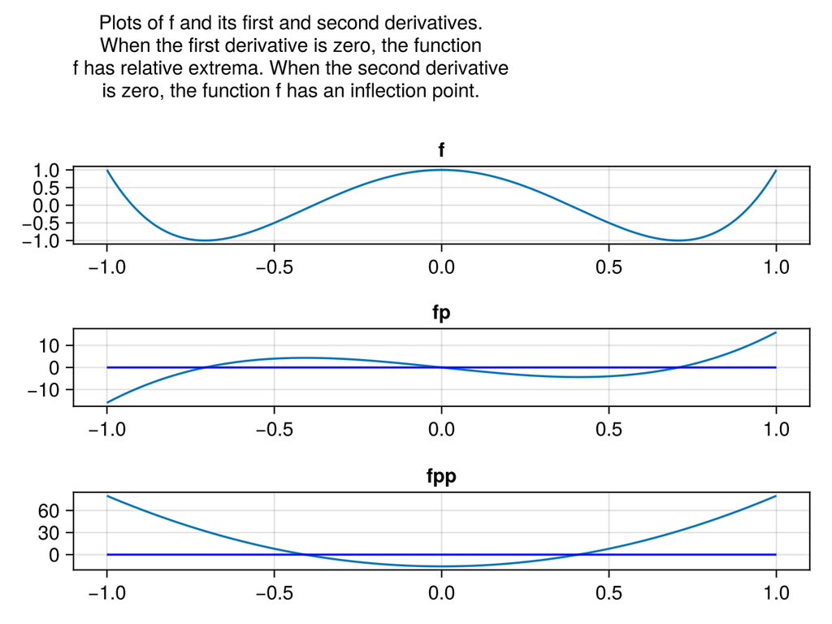

```julia
F
```

Figure 72.44: Figure containing multiple axes

## 72.8 Observables

**NoteThis needs updating**

As over `v"0.24"` of Makie, there is an alternative to using `Observables`. These notes need updating to reflect that change.

The basic components of a plot in `Makie` can be updated [interactively](https://makie.juliaplots.org/stable/documentation/nodes/index.html#observables_interaction). Historically `Makie` used the `Observables` package which allows complicated interactions to be modeled quite naturally. In the following we give a simple example, though newer versions of `Makie` rely on a different mechanism.

In Makie, an `Observable` is a structure that allows its value to be updated, similar to an array. When changed, observables can trigger an event. Observables can rely on other observables, so events can be cascaded.

This simple example shows how an observable `h` can be used to create a collection of points representing a secant line. The figure shows the value for `h=3/2`.

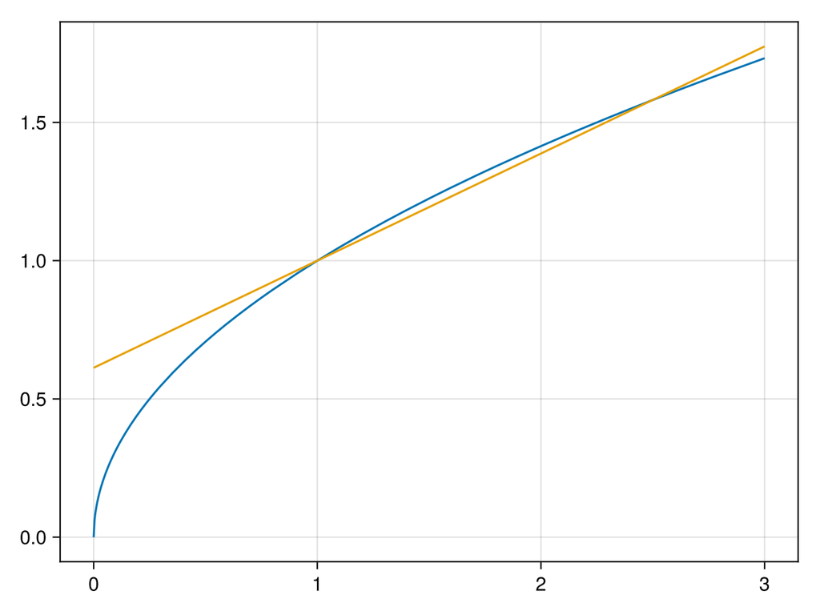

```julia
begin
f(x) = sqrt(x)
c = 1
xs = 0..3
h′ = Observable(3/2)

points = lift(h′) do h
    xs = [0,c,c+h,3]
    tl = x -> f(c) + (f(c+h)-f(c))/h * (x-c)
    [Point2(x, tl(x)) for x ∈ xs]
end

lines(xs, f)
lines!(points)
current_figure()
end
```

Figure 72.45: Illustration of using an `Observable`

We can update the value of `h` using `setindex!` notation (square brackets). For example, to see that the secant line is a good approximation to the tangent line as $h \rightarrow 0$ we can set `h` to be `1/4` and replot in Figure 72.46.

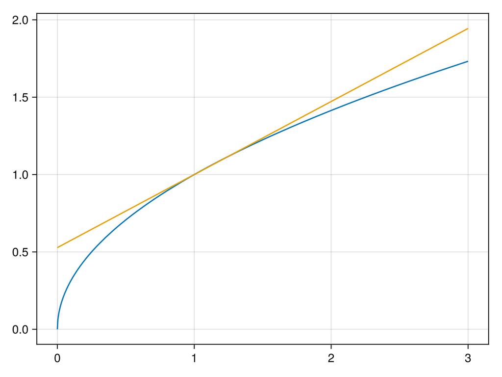

```julia
h′[] = 1/4
current_figure()
```

Figure 72.46: Same plot as in Figure 72.45 with `h'` value updated

The line `h[] = 1/4` updated `h` which then updated `points` (a points is lifted up from `h`) which updated the graphic. (In these notes, we replot to see the change, but in an interactive session, the current *displayed* figure would be updated; no replotting would be necessary.)

Finally, this example shows how to add a slider to adjust the value of `h` with a mouse. The slider object is positioned along with a label using the grid reference, as before.

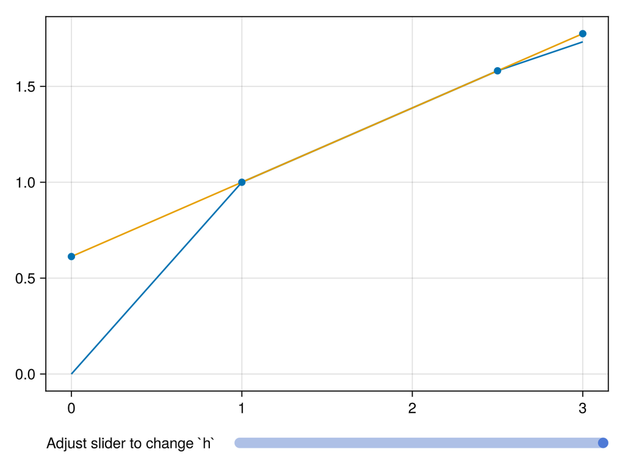

```julia
let
f(x) = sqrt(x)
c = 1
xs = 0..3

F = Figure()
ax = Axis(F[1,1:2])
h = Slider(F[2,2], range = 0.01:0.01:1.5, startvalue = 1.5)
Label(F[2,1], "Adjust slider to change `h`";
      justification = :left)

points = lift(h.value) do h
    xs = [0,c,c+h,3]
    tl = x-> f(c) + (f(c+h)-f(c))/h * (x-c)
    [Point2(x, tl(x)) for x ∈ xs]
end

lines!(ax, xs, f)
lines!(ax, points)
scatter!(ax, points; markersize=10)
    current_figure()
end
```

A slider added in position `F[2,2]` and connected through `lift`

The slider value is “lifted” by its `value` component, as shown. Otherwise, the above is fairly similar to just using an observable for `h`.

[^1]: This example is modified from a [discourse](https://discourse.julialang.org/t/how-to-plot-step-functions-x-correctly-in-julia/84087/5) post by user `@rafael.guerra`.
[^2]: This example annotates the underlying `Axis` object, extracted using tuple destructuring. A more direct approach of creating a `Figure` object and then an `Axis` object will be illustrated later.